# Daniel_Gonzalez_Client_Notebook_1

## Executive Summary

This analysis identifies key patterns in the Madrid real estate market based on more than 100,000 properties. Areas with investment potential are identified, features that influence price (such as a terrace, elevator, or property condition) are analyzed, and a predictive model is proposed to estimate a property's target price.

In this initial step, we select the key variables that will likely drive our analysis, including property location, pricing, physical characteristics, condition, energy certification, visibility (media), and the date when the property was viewed.

We will then calculate the percentage of missing values to understand data quality issues that may require imputation, filtering, or special treatment.

### All data was filtered to include only listings within the city of Madrid, excluding nearby provinces and autonomous communities.

- `price`, `latitude`, `longitude`, `city`, `property_type`, and media-related columns (e.g. `has_virtual_tour`) are fully complete — we can use them directly.
- `price_down_from` is missing in 95.8% of cases, making it unreliable. We'll drop it.
- `quarter`, `floor`, and `district` have moderate levels of missingness. We may:
  - Use them cautiously in analyses where geospatial detail is essential,
  - Consider imputing or grouping by broader geographies (`district` > `quarter`).
- Minor missingness in `n_rooms`, `n_baths`, `area`, `property_state`, and `energy_certificate_state` — we will drop rows with missing values in these, as the proportion is low and imputation would add noise.

We proceed to apply this cleaning strategy next.

### Analyze property price distribution

In this step, we take a closer look at the price variable to understand the range of values, detect potential outliers, and assess its overall distribution.

We will start with basic summary statistics and a histogram.

### Keep only sale listings

The dataset includes both rental and sale listings. Since investment decisions regarding real estate purchases focus on sale properties, we remove all rental entries.

```
['alquiler' 'buy' 'venta' 'rent']
```

### Reinspect price distribution after removing rental listings

Now that we are only considering properties for sale, we revisit the price distribution to check for remaining outliers or extreme luxury properties. This will help us decide on optional filtering thresholds.

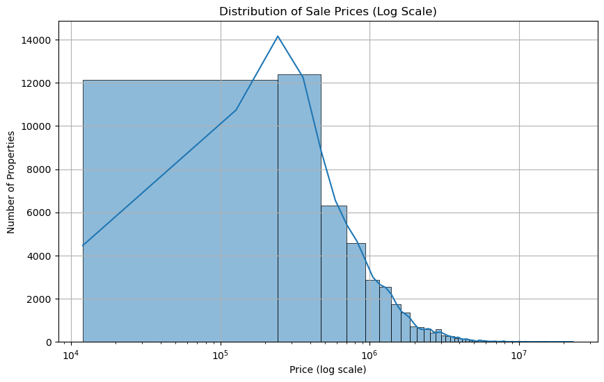

### Create price per square meter (€/m²)

To make prices comparable across properties of different sizes, we create a new column that measures the price per square meter. This will be our primary metric for detecting over- or under-valued areas.

## Summary of Data Cleaning and Property Type Exploration

After exploring and validating the dataset, we reached the following key conclusions:

- We filtered the dataset to retain only properties for **sale**, resulting in 48,905 relevant listings.
- Even after filtering rentals, the price distribution remains heavily right-skewed, with some properties priced above €20M.
- The **median sale price** is ~€445,000, while the **mean** is ~€800,000, indicating the presence of luxury listings.
- We extracted the **true property subtype** from the `ad_title` (e.g., `'piso'`, `'ático'`, `'chalet adosado'`), creating a new column: `property_subtype`.

**Subtype Distribution**

- The dataset contains a healthy mix of property types:
  - `piso` (71%), `chalet adosado`, `ático`, `dúplex`, `estudio`, etc.
  - Only a small fraction (<2%) corresponds to `finca rústica`, `casa rural`, or other rare types.

**Investigation of Low-Price Properties**

- A manual inspection showed that low-price properties (e.g., < €40,000) mostly consist of **valid small apartments** (`piso`) with realistic price-per-square-meter values (e.g., €400–€1,000/m²).
- Therefore, we decided **not to remove these listings**, as they could represent legitimate investment opportunities.

We are now ready to move on to a price-per-square-meter analysis across Madrid's districts.

### Analyze price per square meter by district

We group the data by `district` and calculate average and median price per square meter. This gives us an overview of the relative pricing across different areas of Madrid.

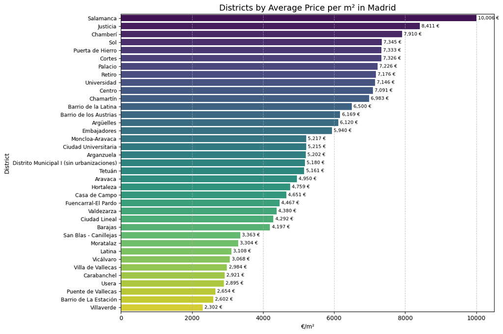

| district | Avg €/m² | Avg Area (m²) | Avg Rooms | % in Good Condition | % with Elevator | % with Floorplan | % with Virtual Tour | Listings Count |
| --- | --- | --- | --- | --- | --- | --- | --- | --- |
| Villaverde | 2301.92 | 77.36 | 2.46 | 0.79 | 0.43 | 0.29 | 0.04 | 1580 |
| Puente de Vallecas | 2654.50 | 72.66 | 2.23 | 0.77 | 0.41 | 0.25 | 0.05 | 2731 |
| Usera | 2894.62 | 84.37 | 2.50 | 0.81 | 0.48 | 0.32 | 0.10 | 1262 |
| Carabanchel | 2920.58 | 96.36 | 2.46 | 0.76 | 0.52 | 0.33 | 0.08 | 2715 |
| Villa de Vallecas | 2984.41 | 99.56 | 2.37 | 0.76 | 0.73 | 0.42 | 0.06 | 1014 |
| Vicálvaro | 3067.66 | 110.25 | 2.73 | 0.42 | 0.73 | 0.67 | 0.03 | 1048 |
| Latina | 3107.89 | 84.84 | 2.59 | 0.80 | 0.59 | 0.27 | 0.07 | 1698 |
| Moratalaz | 3303.58 | 87.75 | 2.81 | 0.87 | 0.66 | 0.25 | 0.08 | 459 |
| San Blas - Canillejas | 3363.39 | 107.75 | 2.45 | 0.78 | 0.61 | 0.35 | 0.10 | 1925 |
| Barajas | 4197.48 | 139.11 | 2.96 | 0.75 | 0.58 | 0.41 | 0.10 | 504 |
| Ciudad Lineal | 4291.58 | 112.81 | 2.69 | 0.73 | 0.69 | 0.43 | 0.09 | 2508 |
| Fuencarral-El Pardo | 4466.80 | 212.64 | 3.45 | 0.75 | 0.65 | 0.48 | 0.13 | 2147 |
| Hortaleza | 4758.59 | 238.43 | 3.36 | 0.83 | 0.68 | 0.48 | 0.16 | 2738 |
| Tetuán | 5160.56 | 109.69 | 2.35 | 0.74 | 0.72 | 0.45 | 0.11 | 3061 |
| Arganzuela | 5201.89 | 90.22 | 2.37 | 0.76 | 0.85 | 0.46 | 0.13 | 2026 |
| Moncloa-Aravaca | 5217.13 | 331.79 | 4.07 | 0.69 | 0.57 | 0.51 | 0.17 | 2487 |
| Chamartín | 6982.64 | 216.08 | 3.48 | 0.72 | 0.79 | 0.50 | 0.18 | 3118 |
| Centro | 7091.47 | 108.04 | 2.34 | 0.87 | 0.70 | 0.45 | 0.12 | 4864 |
| Retiro | 7176.47 | 135.10 | 2.90 | 0.79 | 0.94 | 0.44 | 0.13 | 2045 |
| Chamberí | 7910.18 | 156.32 | 2.98 | 0.79 | 0.92 | 0.45 | 0.11 | 2628 |
| Salamanca | 10005.71 | 159.60 | 2.81 | 0.84 | 0.93 | 0.45 | 0.09 | 6231 |

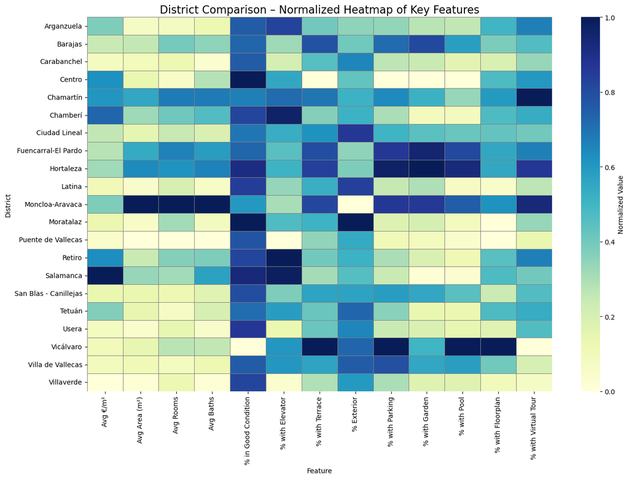

## Strategic Insights by District (Heatmap + Metric Table Summary)

The following conclusions are drawn from a combined analysis of a normalized heatmap and a metric comparison table across the 21 districts of Madrid capital (filtered for listings ≥30):

### Best Price-to-Quality Opportunities

- **Villaverde**
  - **Lowest €/m² (2,301 €)**
  - 79% in good condition, 43% with elevator
  - Weak digital visibility, but high supply (1,580 listings)
  - Great target for high-yield, low-entry investments
- **Usera**
  - 84 m² on average, 2.5 rooms
  - 81% in good condition, better digital presence (10% tours, 32% floorplans)
  - Balanced, undervalued district with upside
- **Carabanchel**
  - 96 m², 76% in good condition, fair visibility
  - Suitable for affordable acquisition with moderate comfort

### Best for Comfort + Large Units

- **Villa de Vallecas**
  - 99 m², 2.4 rooms
  - 73% elevator, 42% with floorplans
  - Good for families or long-term rental
- **Vicálvaro**
  - 110 m², 67% floorplan presence
  - Only 42% in good condition → potential under development
  - Use with filtering by renovation status

### High-End, High-Visibility Districts

- **Retiro, Chamberí, Salamanca**
  - €7,000–€10,000 €/m²
  - +90% elevator, high floorplan coverage
  - Best suited for flipping, premium rentals or repositioning

### Districts to Monitor Closely

- **Puente de Vallecas**
  - Good supply & low €/m²
  - Weak digital presence & average condition
  - Requires careful property-level filtering
- **Vicálvaro**
  - Low condition rate (42%) may mask newer supply or poor upkeep
  - Proceed with careful segmentation

### Summary Table

| Category | Top Districts |
| --- | --- |
| Best Value for Money | Villaverde, Usera, Carabanchel |
| Spacious & Comfortable Units | Villa de Vallecas, Vicálvaro |
| High Visibility & Premium Targets | Retiro, Chamberí, Salamanca |
| Requires Caution | Puente de Vallecas, Vicálvaro |

From now on, we will try to find the best opportunities the market has, we are going to divide this opportunities in 4 groups

- A - "Absolute Bargain
- B – "Cheap in an expensive area"
- C – "Rental Yield"
- D – "Renovable with potential"

We are going to start defining the new metric **expected_price_m2** that we will compare with the old one, **district_avg_price_m2** so we can generate an **undervaluation_score** that will allow us to measure if a certain property could be profitable.

### A - "Absolute Bargain"

**Definition:** Properties whose price per square meter is significantly below their expected value given their characteristics (rooms, condition, extras, digital visibility) and the district average.

**Objective:** Identify apartments clearly undervalued by the market..

**Estimation formula:** expected_price_m2 = district_avg_price_m2 * (1 + ajustes)

**Weights applied:**

- +10% if in "Good condition"
- +10% if it has an elevator
- +5% if it has a terrace
- +4% if it has a floor plan
- +3% if it has more rooms than average (adjusted by z-score)

**Final metric:** undervaluation_score = expected_price_m2 - actual_price_m2

|  | district | price | area | price_per_m2 | expected_price_m2_A | undervaluation_score_A | ad_url |
| --- | --- | --- | --- | --- | --- | --- | --- |
| 171384 | Salamanca | 445600.0 | 180.0 | 2475.555556 | 12661.282995 | 10185.727439 | https://www.idealista.com/inmueble/106650751/ |
| 39658 | Salamanca | 650000.0 | 179.0 | 3631.284916 | 13672.541607 | 10041.256691 | https://www.idealista.com/inmueble/103719385/ |
| 90453 | Salamanca | 475000.0 | 141.0 | 3368.794326 | 13358.120158 | 9989.325831 | https://www.idealista.com/inmueble/100875918/ |
| 178833 | Salamanca | 475000.0 | 141.0 | 3368.794326 | 13358.120158 | 9989.325831 | https://www.idealista.com/inmueble/100875918/ |
| 142559 | Salamanca | 1275000.0 | 402.0 | 3171.641791 | 12957.891758 | 9786.249967 | https://www.idealista.com/inmueble/106445311/ |

### B – "Cheap in an expensive area"

**Definition:** Properties whose price per m² is much lower than the district average, but located in high-value areas (>P75).

**Objective:** Detect cheap apartments in Madrid's most expensive neighborhoods, ideal for flipping or premium rentals.

**Metric:** relative_discount = district_avg_price_m2 - actual_price_m2

**Conditions:**

- Only districts with €/m² > Q3 (p75) are considered
- Those with a difference of at least €1,000/m² are selected

|  | district | price | price_per_m2 | district_avg_price_m2 | relative_discount | ad_url |
| --- | --- | --- | --- | --- | --- | --- |
| 16391 | Salamanca | 450000.0 | 2295.918367 | 10005.71 | 7709.791633 | https://www.idealista.com/inmueble/106134038/ |
| 171384 | Salamanca | 445600.0 | 2475.555556 | 10005.71 | 7530.154444 | https://www.idealista.com/inmueble/106650751/ |
| 82474 | Salamanca | 299000.0 | 2646.017699 | 10005.71 | 7359.692301 | https://www.idealista.com/inmueble/104436782/ |
| 159426 | Salamanca | 190000.0 | 2714.285714 | 10005.71 | 7291.424286 | https://www.idealista.com/inmueble/106392549/ |
| 92314 | Chamberí | 55000.0 | 625.000000 | 7910.18 | 7285.180000 | https://www.idealista.com/inmueble/104628316/ |

### C – "Rental Yield"

**Definition:** Affordable properties, in good condition, with attractive features for tenants (elevator, digital visibility, terrace), ideal for generating good returns.

**Objective:** Find apartments that, without being "extreme bargains," offer a good value for money as an investment.

**Estimated Score:** rental_score = (factores estandarizados que aumentan el atractivo para alquiler)

**Baseline Criteria:**

- Total price < €300,000
- Good condition
- Bedrooms >=2
- Digital visibility (floorplan or tour)

|  | district | price | rental_score | n_rooms | has_elevator | has_floorplan | ad_url |
| --- | --- | --- | --- | --- | --- | --- | --- |
| 21471 | Usera | 210000.0 | 1.0 | 3.0 | True | True | https://www.idealista.com/inmueble/101827180/ |
| 68070 | Ciudad Lineal | 270000.0 | 1.0 | 2.0 | True | True | https://www.idealista.com/inmueble/103177775/ |
| 89018 | Puente de Vallecas | 289000.0 | 1.0 | 2.0 | True | True | https://www.idealista.com/inmueble/100935499/ |
| 87184 | Usera | 220000.0 | 1.0 | 2.0 | True | True | https://www.idealista.com/inmueble/106675047/ |
| 80551 | Puente de Vallecas | 285000.0 | 1.0 | 3.0 | True | True | https://www.idealista.com/inmueble/106601652/ |

### D – "Renovable with potential"

**Definition:** Properties in poor condition located in areas with a medium-high average price, whose price per square meter is below the district average. Good candidates for renovation and revaluation.

**Objective:** Identify units where the renovation could generate a clear post-renovation margin.

**Conditions:**

- `property_state` other than "Good condition"
- District with an average price > €4,000/square meter
- Significant difference from the district average

|  | district | price | price_per_m2 | property_state | district_avg_price_m2 | ad_url |
| --- | --- | --- | --- | --- | --- | --- |
| 163699 | Ciudad Lineal | 50000.0 | 704.225352 | A reformar | 4291.58 | https://www.idealista.com/inmueble/105306704/ |
| 103688 | Ciudad Lineal | 55000.0 | 774.647887 | A reformar | 4291.58 | https://www.idealista.com/inmueble/105306704/ |
| 84916 | Ciudad Lineal | 55000.0 | 774.647887 | A reformar | 4291.58 | https://www.idealista.com/inmueble/105306704/ |
| 27873 | Ciudad Lineal | 392000.0 | 1104.225352 | A reformar | 4291.58 | https://www.idealista.com/inmueble/105960846/ |
| 146535 | Ciudad Lineal | 180000.0 | 1118.012422 | A reformar | 4291.58 | https://www.idealista.com/inmueble/102669935/ |

With all this data, we can now create a series of visualizations that can show us key districts based on what we are looking for.

### 1) District Comparison: Quality vs. Digital Visibility

**Objective:** To see if the districts with the highest percentage of homes in good condition also stand out for their digital presence (floorplans and virtual tours).

- X-axis: % in good condition
- Y-axis: % with floorplan
- Size: number of properties
- Color: % with virtual tours

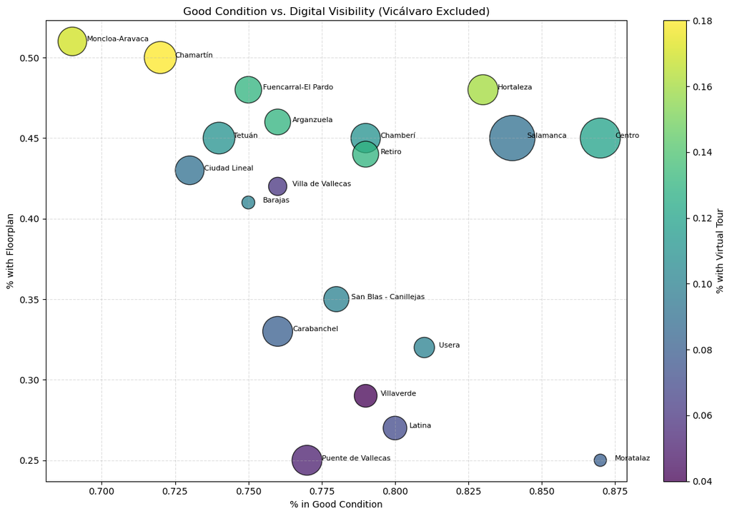

### Good Condition vs. Digital Visibility

> **Objective:** Identify districts that combine good physical condition with digital visibility (plans and virtual tours).

#### Business Insight:

> **Prioritize districts with high physical quality but low digital presence**, such as Moratalaz, to capture undervalued or uncompetitive properties online.

### 2) District Comparison: Price vs. Average Size

**Objective:** Analyze which districts offer the largest average surface area at the lowest price per square meter.

- X-axis: Average price per square meter
- Y-axis: Average surface area
- Size: Number of listings
- Color: Average rooms

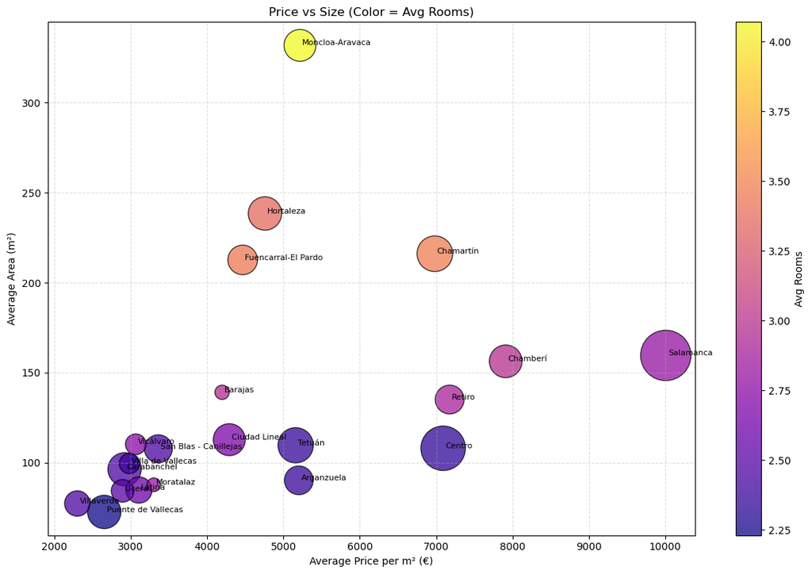

### Price per m² vs. Average Area (Color = Average Rooms)

> **Objective:** To identify areas with the best surface-to-price ratio, adjusted by the number of rooms.

### 3) District Comparison: Price vs. Comfort (Elevator)

**Objective:** See if there are districts with a higher percentage of properties with an elevator while maintaining low prices.

- X-axis: Average price per square meter
- Y-axis: % with elevator
- Size: Number of listings
- Color: % in good condition

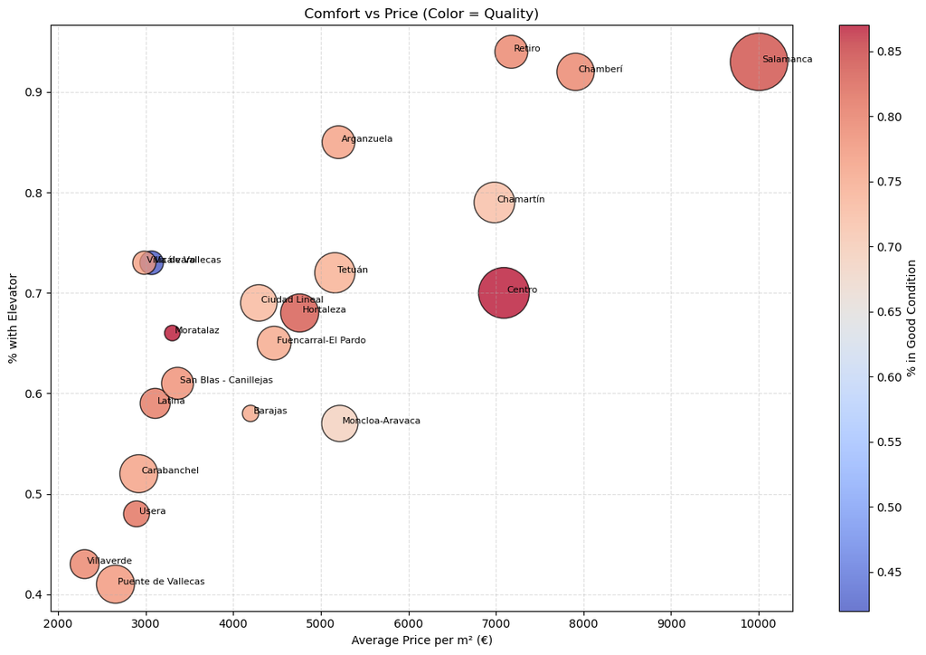

### Comfort vs. Price (Color = % in Good Condition)

> **Objective:** Find neighborhoods that are comfortable (elevator) and in good condition, without paying premium prices.

#### Key Takeaways:

- **Top quality and comfort (expensive):** Salamanca, Retiro, Chamberí

→ +90% with elevators and very good condition, but very high prices.

- **Ideal Balance:** Arganzuela, Chamartín, Centro

→ Good comfort, many homes in good condition, and more reasonable prices than the top neighborhoods.

- **Growth Potential:** Tetuán, Ciudad Lineal, Fuencarral-El Pardo

→ They combine medium-high quality, intermediate prices, and room for appreciation.

- **Low prices, room for improvement:** Usera, Villaverde, Puente de Vallecas

→ Very low prices, but less comfort. A riskier investment, ideal for renovations.

#### Investment Insight:

> **Best comfort-quality-price ratio in: Chamartín, Arganzuela, and Tetuán.**

## Final Conclusions and Recommended Opportunities

After the full analysis, four opportunity profiles stand out:

- **Bargains (Type A):** undervalued relative to their quality and location.
- **Cheap in an expensive area (Type B):** opportunities within expensive districts.
- **Rental Yield (Type C):** affordable, in good condition, attractive to tenants.
- **Renovable with potential (Type D):** with room for appreciation after renovation.

[interactive chart not shown]

### Predictive Model – Estimating Property Prices

As a final step, we built a basic predictive model to estimate the price of a property based on its physical features and location. This serves to:

- Validate the importance of the variables analyzed
- Estimate expected price ranges
- Identify undervalued listings based on predicted vs actual prices

We used a **Random Forest Regressor** with the following features:

- Property characteristics: `area`, `n_rooms`, `n_baths`, `floor`
- Amenities: `has_terrace`, `has_garden`, `has_elevator`
- Digital visibility: `has_floorplan`, `has_virtual_tour`
- Location: encoded `district`
- Orientation: `is_exterior`
- Certification status: `has_energy_certificate`

The model achieved the following performance:

- **Mean Absolute Error (MAE):** 82,990 €
- **R² Score:** 0.910 (indicates the proportion of price variance explained)

This predictive baseline could be used to flag listings whose real price deviates significantly from the predicted one — a useful tool for surfacing potential investment opportunities.

### Model-Based Opportunity Detection – Undervalued Listings

Based on the trained model (R² = 0.91), we compared the predicted price to the actual listing price in the test set.

By sorting properties where the actual price is **significantly lower** than the predicted price, we can detect potential investment "sweet spots".

These properties are not just cheap — they’re cheap **according to the model**, making them prime candidates for deeper due diligence and potential acquisition.

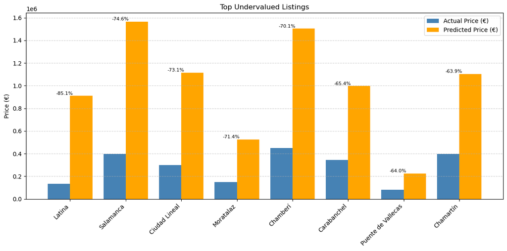

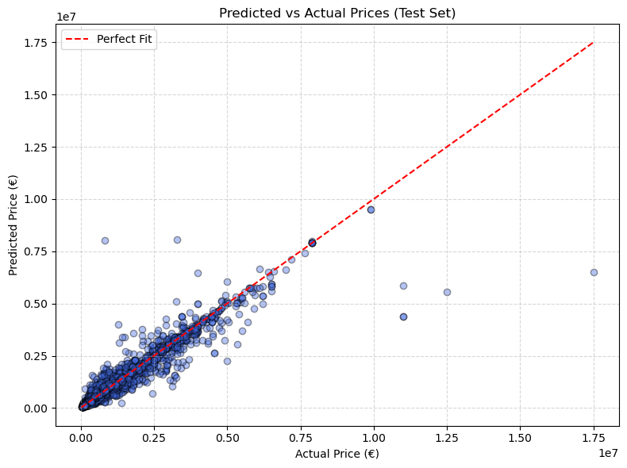

### Model Validation and Opportunity Detection

To ensure the robustness of the predictive model, we validated its performance by comparing actual vs. predicted prices on the test set.

#### Scatter Plot – Predicted vs. Actual Prices

This plot shows how well the model estimates prices across the dataset:

- Most points cluster around the red diagonal (`Perfect Fit`), indicating strong model accuracy.
- A few outliers remain, which is expected in a market with both luxury properties and undervalued listings.
- The model achieves:
  - **MAE ≈ 83K €**
  - **R² ≈ 0.91**, suggesting it explains over 90% of the variance in prices.

#### Strategic Use of This Model

We filtered listings where the actual price is significantly **lower than the model’s prediction** and excluded extreme outliers.  
This approach helps us flag **data-driven investment opportunities**, not just cheap properties, but those which are **unusually cheap given their features and location**.

Combined with visual, location and quality analyses, this becomes a powerful tool for identifying potential deals.

### Visual Analysis – Model-Detected Undervalued Properties

- Blue bars represent the **actual listing price**
- Orange bars show the **model’s predicted price**
- Percentage above each group represents the deviation

These properties stand out as statistically undervalued — not just cheap in absolute terms, but unusually low **given their size, features and location**.

## Summary – Investment Insights for Rapada Partners

After a comprehensive analysis of over 48,000 property listings in the city of Madrid, we identified four key types of high-potential investment opportunities.

### 1. Strategic Opportunity Types

The portfolio of investment-ready listings was classified into four categories, each offering a different kind of return potential:

- **Bargains (Type A):** Properties that are significantly undervalued compared to their condition, size, and features.
- **Cheap in an expensive area (Type B):** Listings priced well below the average €/m² within high-value districts.
- **Rental Yield (Type C):** Affordable, well-equipped properties ideal for long-term rental investment.
- **Renovable with potential (Type D):** Properties in need of renovation but located in districts with strong value appreciation.

### 3. Suggested Next Steps

- Review and analyze the **20 highlighted listings** across the 4 opportunity types (interactive map).
- Align acquisition strategy depending on the risk/return profile of the fund:
  - Conservative → Focus on Type C
  - Opportunistic → Prioritize Type A and D